# matrix_heat_map

**Problem 1.** A fixed one-way treatment structure in a RCBD with 3 levels and with 5 reps.

1. Univariate notation

$$y_{ij} = \mu + \alpha_{i} + \beta_{j} + e_{ij}$$

$i = 1,\ 2,\ 3$ $j = 1,\ 2,\ \ldots,\ 5$

$e_{ij}\sim N(0,\sigma_{e}^{2})$ $\beta_{j}\sim N(0,\sigma_{b}^{2})$

$$var(y_{ij}) = var(\mu + \alpha_{i} + \beta_{j} + e_{ij})$$

But $\alpha_{i},\ \beta_{j},and\ e_{ij}$ are mutually independent.

$$var(y_{ij}) = var(\mu) + {var(\alpha}_{i}) + var(\beta_{j}) + {var(e}_{ij})$$

$$\mu\ and\ \alpha_{i}\ are\ fixed,\ var(\mu) = var\left( \alpha_{i} \right) = 0$$

$$var\left( y_{ij} \right) = \sigma_{b}^{2} + \sigma_{e}^{2}$$

$$var({\overline{y}}_{i.}) = var(\mu + \alpha_{i} + {\overline{\beta}}_{.} + {\overline{e}}_{i.})$$

$$var\left( {\overline{y}}_{i.} \right) = var\left( {\overline{\beta}}_{.} \right) + var({\overline{e}}_{i.})$$

$$var\left( {\overline{y}}_{i.} \right) = \frac{\sigma_{b}^{2}}{5} + \frac{\sigma_{e}^{2}}{5}$$

2. For t = 3, N= 5, var(β) = 12, var(e) = 3 the heatmaps for X, Z, G, R, and var(y) are shown below:

**SAS code**

`proc iml ;`

`X = j(3, 1, 1)@j(5, 1, 1)||I(3)@j(5, 1, 1);`

`Z = j(3, 1, 1)@I(5) ;`

`G = 12*I(5) ;`

`R = 3*I(15) ;`

`var_y = 12*(j(3, 3, 1)@I(5))+3*I(15) ;`

`run WriteMatrixInLongForm(X, "X");`

`run WriteMatrixInLongForm(Z, "Z");`

`run WriteMatrixInLongForm(G, "G");`

`run WriteMatrixInLongForm(R, "R");`

`run WriteMatrixInLongForm(var_y, "VARy");`

`quit ;`

`title "Problem 1 - Heatmap for X";`

`proc sgrender data=X template=HeatmapDisc;`

`dynamic _X="col" _Y="row" _Z="X";`

`run;`

`title "Problem 1 - Heatmap for Z";`

`proc sgrender data=Z template=HeatmapDisc;`

`dynamic _X="col" _Y="row" _Z="X";`

`run;`

`title "Problem 1 - Heatmap for G";`

`proc sgrender data=G template=HeatmapDisc;`

`dynamic _X="col" _Y="row" _Z="X";`

`run;`

`title "Problem 1 - Heatmap for R";`

`proc sgrender data=R template=HeatmapDisc;`

`dynamic _X="col" _Y="row" _Z="X";`

`run;`

`title "Problem 1 - Heatmap for Var(y)";`

`proc sgrender data=VARy template=HeatmapDisc;`

`dynamic _X="col" _Y="row" _Z="X";`

`run;`

Problem 1 - Heatmap for X

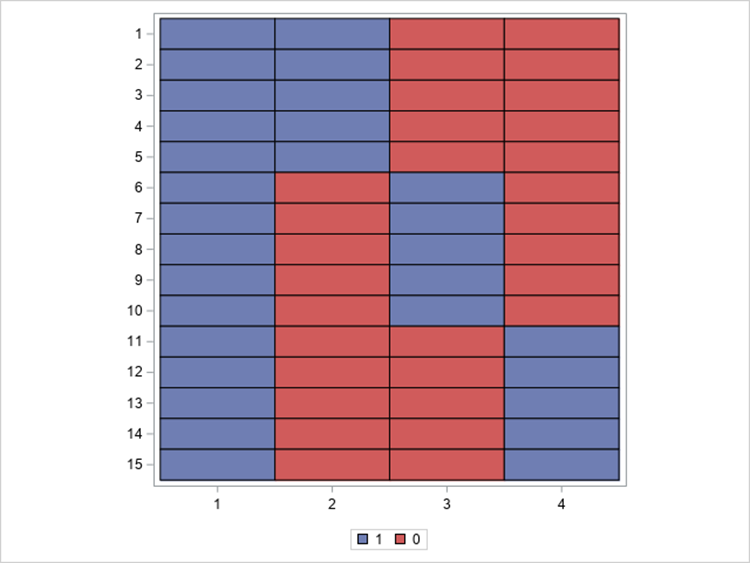

Problem 1 - Heatmap for Z

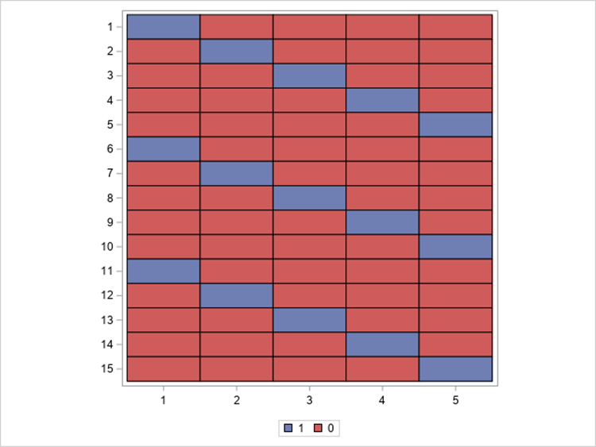

Problem 1 - Heatmap for G

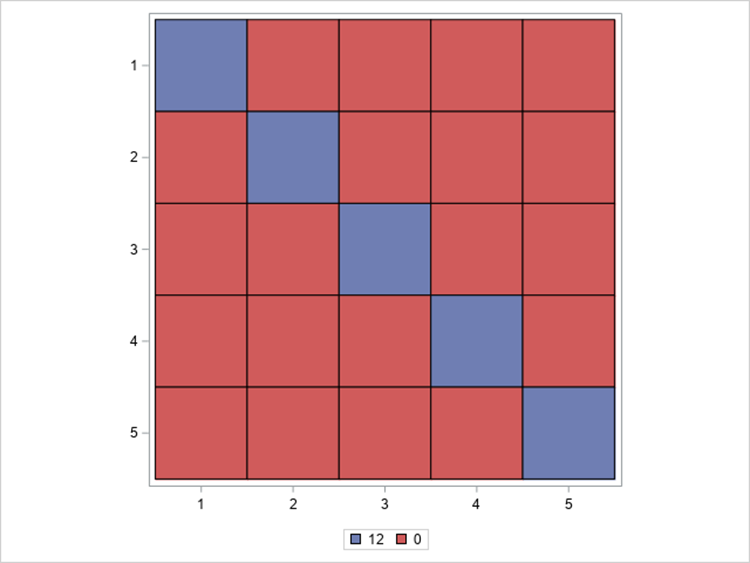

Problem 1 - Heatmap for R

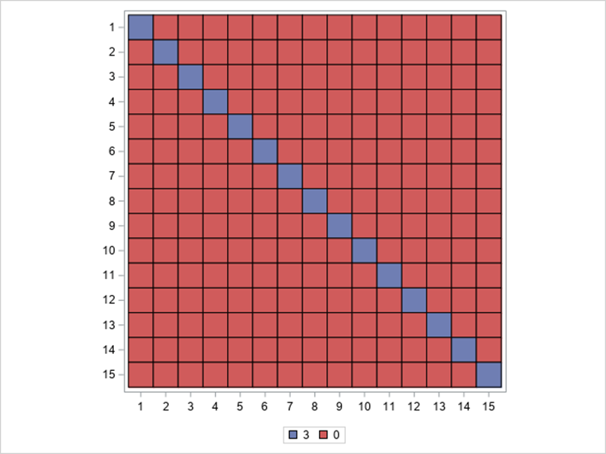

Problem 1 - Heatmap for Var(y)

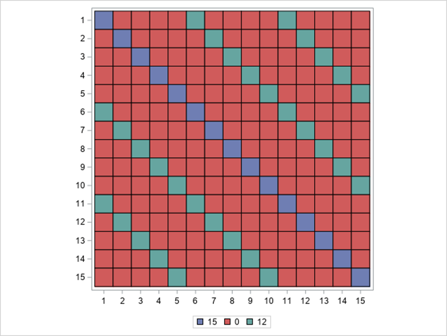

**Problem 2.** 2 x 3 factorial treatment structure (A is fixed and B is random) in a CRD with 10 reps.

1. Univariate notation

$$y_{ijk} = \mu + \alpha_{i} + b_{j} + {(\alpha b)}_{ij} + e_{ijk}$$

$i = 1, 2$ $j = 1,\ 2,\ 3$ $k = 1,\ 2,\ \ldots,\ 10$

$e_{ijk}\sim N(0,\sigma_{e}^{2})$ $b_{j}\sim N(0,\sigma_{b}^{2})$ ${\alpha b}_{ij}\sim N(0,\sigma_{\alpha b}^{2})$

$$var(y_{ijk}) = var(\mu + \alpha_{i} + b_{j} + {(\alpha b)}_{ij} + e_{ijk})$$

But $\alpha_{i},\ b_{j},{(\alpha b)}_{ij},\ and\ e_{ijk}$ are mutually independent.

$$var(y_{ijk}) = var(\mu) + {var(\alpha}_{i}) + var(b_{j}) + var({(\alpha b)}_{ij}) + {var(e}_{ijk})$$

$$\mu\ and\ \alpha_{i}\ are\ fixed,\ var(\mu) = var\left( \alpha_{i} \right) = 0$$

$$var\left( y_{ijk} \right) = \sigma_{b}^{2} + \sigma_{\alpha b}^{2} + \sigma_{e}^{2}$$

$$var({\overline{y}}_{i..}) = var(\mu + \alpha_{i} + {\overline{b}}_{.} + {(\overline{\alpha b})}_{i.} + {\overline{e}}_{i..})$$

$$var\left( {\overline{y}}_{i..} \right) = var\left( {\overline{b}}_{.} \right) + var{((\overline{\alpha b})}_{i.}) + var({\overline{e}}_{i..})$$

$$var\left( {\overline{y}}_{i.} \right) = \frac{\sigma_{b}^{2}}{3} + \frac{\sigma_{\alpha b}^{2}}{3} + \frac{\sigma_{e}^{2}}{30}$$

2. For a = 2, b = 3, N = 10, var(B) = 15, var(AB) = 4, var(e) = 6 the heatmaps for X, Z, G, R, and var(y) are shown below:

**SAS code**

`proc iml ;`

`X = j(2, 1, 1)@j(3, 1, 1)@j(10, 1, 1)||I(2)@j(3, 1, 1)@j(10, 1, 1) ;`

`Z = j(2, 1, 1)@I(3)@j(10, 1, 1)||I(2)@I(3)@j(10, 1, 1) ;`

`G = BLOCK(15*I(3), 4*I(6));`

`R = 6*I(60) ;`

`` var_y = Z*G*Z` + R ; ``

`run WriteMatrixInLongForm(X, "X");`

`run WriteMatrixInLongForm(Z, "Z");`

`run WriteMatrixInLongForm(G, "G");`

`run WriteMatrixInLongForm(R, "R");`

`run WriteMatrixInLongForm(var_y, "VARy");`

`quit ;`

`title "Problem 2 - Heatmap for X";`

`proc sgrender data=X template=HeatmapDisc;`

`dynamic _X="col" _Y="row" _Z="X";`

`run;`

`title "Problem 2 - Heatmap for Z";`

`proc sgrender data=Z template=HeatmapDisc;`

`dynamic _X="col" _Y="row" _Z="X";`

`run;`

`title "Problem 2 - Heatmap for G";`

`proc sgrender data=G template=HeatmapDisc;`

`dynamic _X="col" _Y="row" _Z="X";`

`run;`

`title "Problem 2 - Heatmap for R";`

`proc sgrender data=R template=HeatmapDisc;`

`dynamic _X="col" _Y="row" _Z="X";`

`run;`

`title "Problem 2 - Heatmap for Var(y)";`

`proc sgrender data=VARy template=HeatmapDisc;`

`dynamic _X="col" _Y="row" _Z="X";`

`run;`

Problem 2 - Heatmap for X

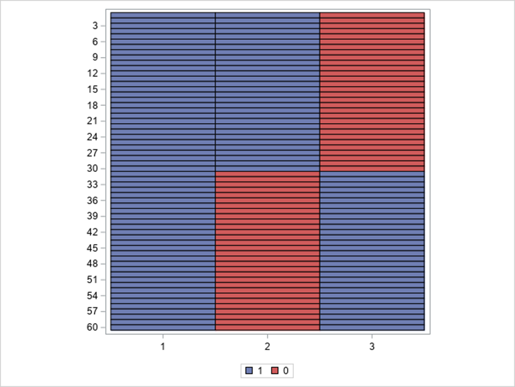

Problem 2 - Heatmap for Z

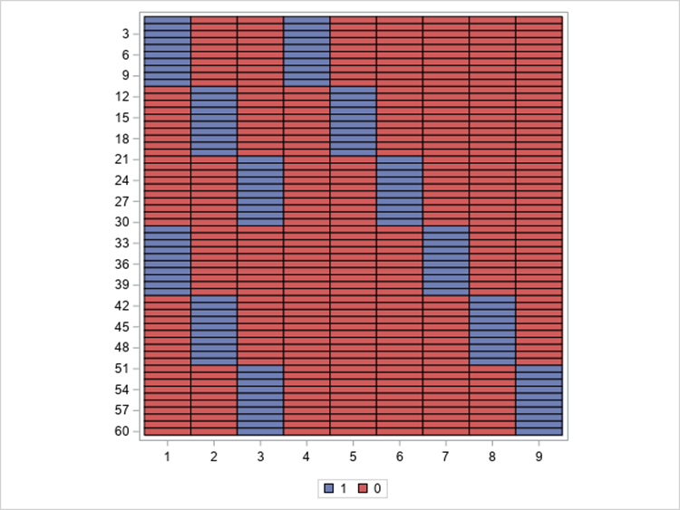

Problem 2 - Heatmap for G

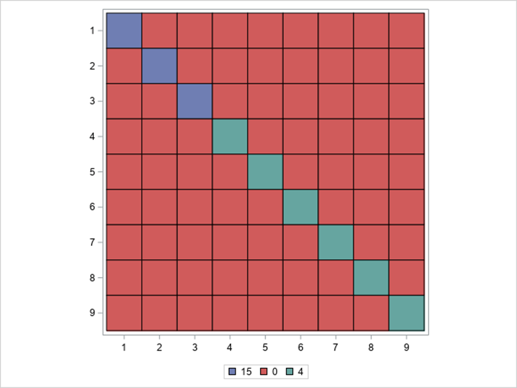

Problem 2 - Heatmap for R

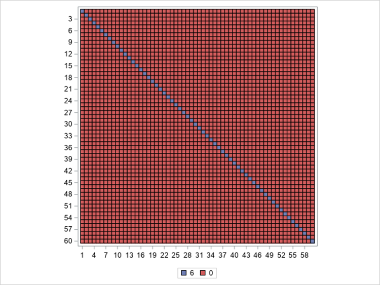

Problem 2 - Heatmap for Var(y)

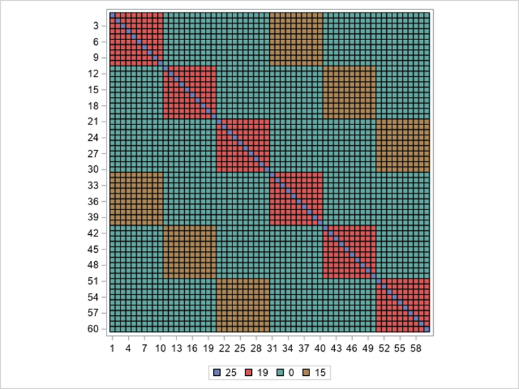

**Problem 3.** 2 x 3 factorial treatment structure (A is random and B is random) in a CRD with 10 reps.

1. Univariate notation

$$y_{ijk} = \mu + \alpha_{i} + b_{j} + {(\alpha b)}_{ij} + e_{ijk}$$

$i = 1, 2$ $j = 1,\ 2,\ 3$ $k = 1,\ 2,\ \ldots,\ 10$

$e_{ijk}\sim N\left( 0,\sigma_{e}^{2} \right)\ \ \ a_{i}\sim N(0,\sigma_{a}^{2})$ $b_{j}\sim N(0,\sigma_{b}^{2})$ ${\alpha b}_{ij}\sim N(0,\sigma_{ab}^{2})$

$$var(y_{ijk}) = var(\mu + a_{i} + b_{j} + {(\alpha b)}_{ij} + e_{ijk})$$

But $a_{i},\ b_{j},{(ab)}_{ij},\ and\ e_{ijk}$ are mutually independent.

$$var(y_{ijk}) = var(\mu) + {var(a}_{i}) + var(b_{j}) + var({(ab)}_{ij}) + {var(e}_{ijk})$$

$$var\left( y_{ijk} \right) = \sigma_{a}^{2} + \sigma_{b}^{2} + \sigma_{ab}^{2} + \sigma_{e}^{2}$$

$$var({\overline{y}}_{i..}) = var(\mu + a_{i} + {\overline{b}}_{.} + {(\overline{ab})}_{i.} + {\overline{e}}_{i..})$$

$$var\left( {\overline{y}}_{i..} \right) = var\left( {\overline{a}}_{.} \right) + var\left( {\overline{b}}_{.} \right) + var{((\overline{ab})}_{i.}) + var({\overline{e}}_{i..})$$

$$var\left( {\overline{y}}_{i.} \right) = \sigma_{a}^{2} + \frac{\sigma_{b}^{2}}{3} + \frac{\sigma_{ab}^{2}}{3} + \frac{\sigma_{e}^{2}}{30}$$

2. For a = 2, b = 3, N = 10, var(A) = 20, var(B) = 15, var(AB) = 4, var(e) = 6 the heatmaps for X, Z, G, R, and var(y) are shown below:

**SAS code**

`proc iml ;`

`X = j(2, 1, 1)@j(3, 1, 1)@j(10, 1, 1) ;`

`Z = I(2)@j(3, 1, 1)@j(10, 1, 1)||j(2, 1, 1)@I(3)@j(10, 1, 1)||I(2)@I(3)@j(10, 1, 1) ;`

`G = BLOCK(20*I(2),15*I(3),4*I(6));`

`R = 6*I(60) ;`

`` var_y = Z*G*Z` + R ; ``

`run WriteMatrixInLongForm(X, "X");`

`run WriteMatrixInLongForm(Z, "Z");`

`run WriteMatrixInLongForm(G, "G");`

`run WriteMatrixInLongForm(R, "R");`

`run WriteMatrixInLongForm(var_y, "VARy");`

`quit ;`

`title "Problem 3 - Heatmap for X";`

`proc sgrender data=X template=HeatmapDisc;`

`dynamic _X="col" _Y="row" _Z="X";`

`run;`

`title "Problem 3 - Heatmap for Z";`

`proc sgrender data=Z template=HeatmapDisc;`

`dynamic _X="col" _Y="row" _Z="X";`

`run;`

`title "Problem 3 - Heatmap for G";`

`proc sgrender data=G template=HeatmapDisc;`

`dynamic _X="col" _Y="row" _Z="X";`

`run;`

`title "Problem 3 - Heatmap for R";`

`proc sgrender data=R template=HeatmapDisc;`

`dynamic _X="col" _Y="row" _Z="X";`

`run;`

`title "Problem 3 - Heatmap for Var(y)";`

`proc sgrender data=VARy template=HeatmapDisc;`

`dynamic _X="col" _Y="row" _Z="X";`

`run;`

Problem 3 - Heatmap for X

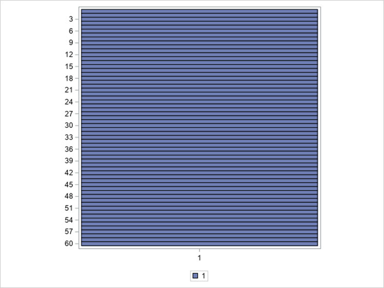

Problem 3 - Heatmap for Z

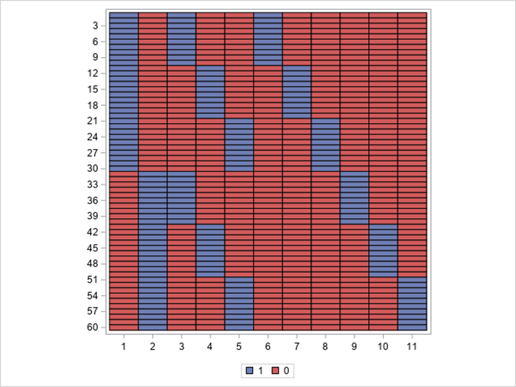

Problem 3 - Heatmap for G

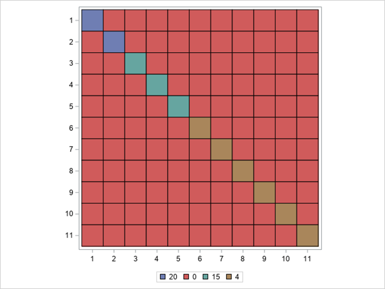

Problem 3 - Heatmap for R

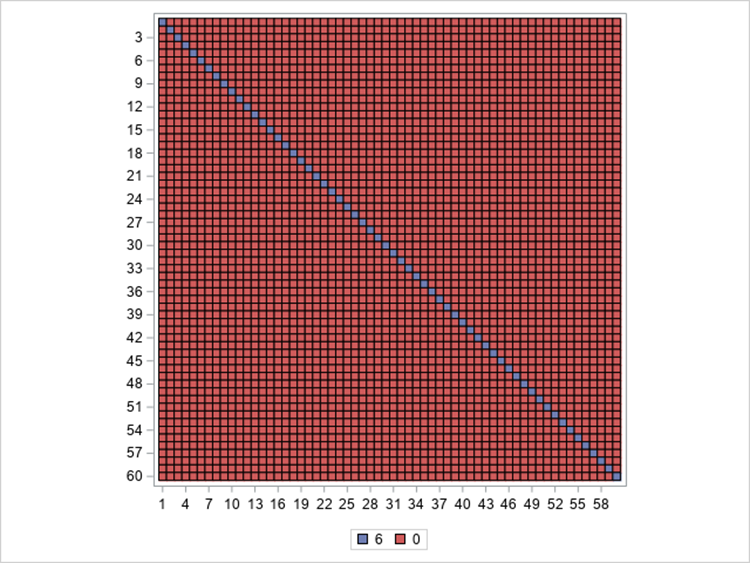

Problem 3 - Heatmap for Var(y)

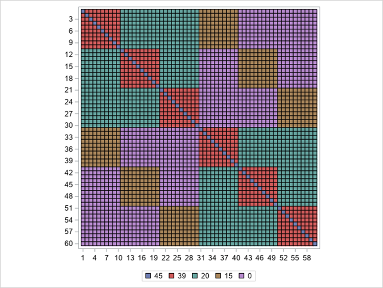

**Problem 4.** 2 x 3 factorial treatment structure (A is fixed and B is fixed) in a CRD with 4 reps.

1. Univariate notation

$$y_{ijk} = \mu + \alpha_{i} + \beta_{j} + {(\alpha\beta)}_{ij} + d_{k(i)} + e_{ijk}$$

$i = 1, 2$ $j = 1,\ 2,\ 3$ $k = 1,\ 2,\ 3,\ 4$

$$var(y_{ijk}) = var(\mu + \alpha_{i} + \beta_{j} + {(\alpha\beta)}_{ij} + d_{k(i)} + e_{ijk})$$

But $\alpha_{i},\ \beta_{j},{(\alpha\beta)}_{ij},d_{k(i)},\ and\ e_{ijk}$ are mutually independent.

$$var(y_{ijk}) = var(\mu) + {var(\alpha}_{i}) + var(\beta_{j}) + var({(\alpha\beta)}_{ij}) + var(d_{k(i)}) + {var(e}_{ijk})$$

$$\mu,\ \alpha_{i},\ \beta_{j},\ and{(\alpha\beta)}_{ij}\ are\ fixed,\ var = 0$$

$$var\left( y_{ijk} \right) = \sigma_{d}^{2} + \sigma_{e}^{2}$$

$$var({\overline{y}}_{i..}) = var(\mu + \alpha_{i} + {\overline{\beta}}_{.} + {(\overline{\alpha\beta})}_{i.} + {\overline{d}}_{.(i)} + {\overline{e}}_{i..})$$

$$var\left( {\overline{y}}_{i..} \right) = var{(\overline{d}}_{.(i)}) + var({\overline{e}}_{i..})$$

$$var\left( {\overline{y}}_{i.} \right) = \frac{\sigma_{d}^{2}}{4} + \frac{\sigma_{e}^{2}}{12}$$

**SAS code**

`proc iml ;`

`X = j(2, 1, 1)@j(3, 1, 1)@j(4, 1, 1)||I(2)@j(3, 1, 1)@j(4, 1, 1)||j(2, 1, 1)@I(3)@j(4, 1, 1)||I(2)@I(3)@j(4, 1, 1) ;`

`Z = I(2)@j(3, 1, 1)@I(4) ;`

`G = 2*I(8);`

`R = 5*I(24) ;`

`` var_y = Z*G*Z` + R ; ``

`run WriteMatrixInLongForm(X, "X");`

`run WriteMatrixInLongForm(Z, "Z");`

`run WriteMatrixInLongForm(G, "G");`

`run WriteMatrixInLongForm(R, "R");`

`run WriteMatrixInLongForm(var_y, "VARy");`

`quit ;`

`title "Problem 4 - Heatmap for X";`

`proc sgrender data=X template=HeatmapDisc;`

`dynamic _X="col" _Y="row" _Z="X";`

`run;`

`title "Problem 4 - Heatmap for Z";`

`proc sgrender data=Z template=HeatmapDisc;`

`dynamic _X="col" _Y="row" _Z="X";`

`run;`

`title "Problem 4 - Heatmap for G";`

`proc sgrender data=G template=HeatmapDisc;`

`dynamic _X="col" _Y="row" _Z="X";`

`run;`

`title "Problem 4 - Heatmap for R";`

`proc sgrender data=R template=HeatmapDisc;`

`dynamic _X="col" _Y="row" _Z="X";`

`run;`

title “Problem 4 - Heatmap for Var(y)”;

**proc** **sgrender** data=VARy template=HeatmapDisc;

dynamic _X=“col” _Y=“row” _Z=“X”;

**run**;

**quit**;

Problem 4 - Heatmap for X

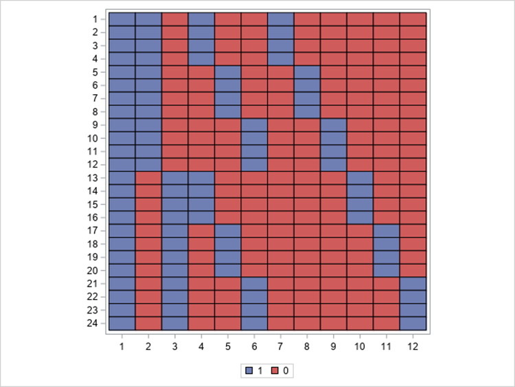

Problem 4 - Heatmap for Z

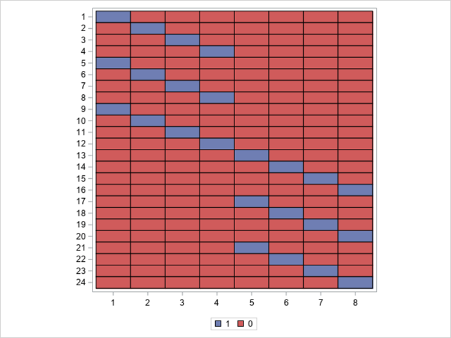

Problem 4 - Heatmap for G

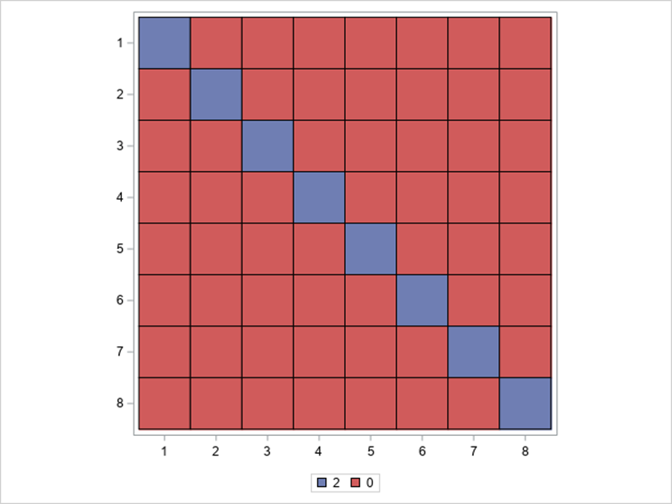

Problem 4 - Heatmap for R

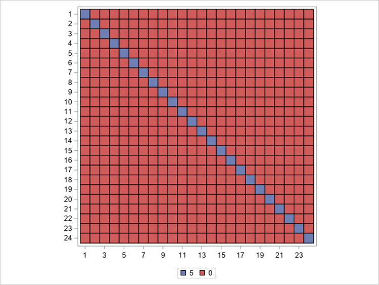

Problem 4 - Heatmap for Var(y)

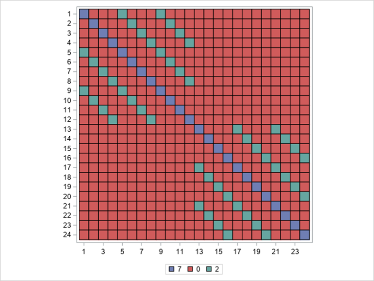